# Обзор бизнес-показателей маркетплейса

### 4.6 Категории товаров

Чтобы понять, какие товары привлекают пользователей и где мы теряем прибыль, рассмотрим распределение заказов и выручки по категориям.

- Чтобы понять структуру продаж, нам нужно посмотреть на две метрики: объем выручки и конверсию из просмотра в покупку для всего маркетплейса.

```python
# Добавляем категорию товара в таблицу событий
product_category_dict = orders_channels_df[['product_name', 'category_name']].drop_duplicates()

events_with_cat = events_channels_df.merge(product_category_dict, on='product_name', how='left')

# Считаем общие просмотры по категориям
total_cat_views = (
    events_with_cat[events_with_cat['event_type'] == 'product_view']
    .groupby('category_name')['user_id']
    .nunique()
    .reset_index(name='total_viewers')
)

# Считаем общие покупки и выручку
total_cat_sales = (
    orders_channels_df
    .groupby('category_name')
    .agg({'user_id': 'nunique', 'total_price': 'sum'})
    .reset_index()
    .rename(columns={'user_id': 'total_buyers', 'total_price': 'revenue'})
)

# Объединяем и считаем общую конверсию
total_category_df = total_cat_views.merge(total_cat_sales, on='category_name', how='left').fillna(0)
total_category_df['conversion_%'] = (total_category_df['total_buyers'] / total_category_df['total_viewers'] * 100).round(2)

# Сортируем по выручке, чтобы увидеть самые важные категории
total_category_rev = total_category_df.sort_values(by='revenue', ascending=False)
total_category_conv = total_category_df.sort_values(by='conversion_%', ascending=False)

display(total_category_rev)
```

|  | category_name | total_viewers | total_buyers | revenue | conversion_% |
| --- | --- | --- | --- | --- | --- |
| 11 | Мебель для дома | 3765 | 498 | 69144429.45 | 13.23 |
| 2 | Бытовая техника | 3724 | 529 | 43417266.33 | 14.21 |
| 24 | Украшения и часы | 3738 | 475 | 32874026.94 | 12.71 |
| 23 | Товары для туризма | 3845 | 487 | 22232400.31 | 12.67 |
| 18 | Спортивный инвентарь | 3842 | 507 | 22044220.52 | 13.20 |
| 0 | Автотовары | 3849 | 541 | 19986765.45 | 14.06 |
| 21 | Товары для кухни | 3834 | 621 | 19862870.76 | 16.20 |
| 15 | Обувь мужская | 3775 | 698 | 17829700.48 | 18.49 |
| 20 | Сумки и аксессуары | 3821 | 688 | 16844195.82 | 18.01 |
| 14 | Обувь женская | 3871 | 736 | 16703297.90 | 19.01 |
| 8 | Инструменты и садовый инвентарь | 3717 | 486 | 15724010.14 | 13.08 |
| 3 | Декор и освещение | 3806 | 523 | 13582767.12 | 13.74 |
| 1 | Аксессуары для гаджетов | 3860 | 706 | 13393235.00 | 18.29 |
| 6 | Женская одежда | 3793 | 624 | 13175894.95 | 16.45 |
| 22 | Товары для новорожденных | 3897 | 681 | 11885764.18 | 17.47 |
| 17 | Продукты питания | 3830 | 2584 | 11540985.39 | 67.47 |
| 16 | Одежда для спорта | 3868 | 712 | 10424136.99 | 18.41 |
| 10 | Косметика и парфюмерия | 3821 | 614 | 9308011.51 | 16.07 |
| 5 | Детские игрушки | 3791 | 538 | 8433913.11 | 14.19 |
| 13 | Мужская одежда | 3795 | 575 | 8215447.50 | 15.15 |
| 7 | Зоотовары | 3840 | 865 | 7206672.11 | 22.53 |
| 12 | Медицинские товары | 3766 | 529 | 6641690.44 | 14.05 |
| 4 | Детская одежда | 3854 | 913 | 6127478.19 | 23.69 |
| 9 | Книги и канцтовары | 3856 | 723 | 3947539.12 | 18.75 |
| 19 | Средства для ухода | 3800 | 627 | 3119748.31 | 16.50 |

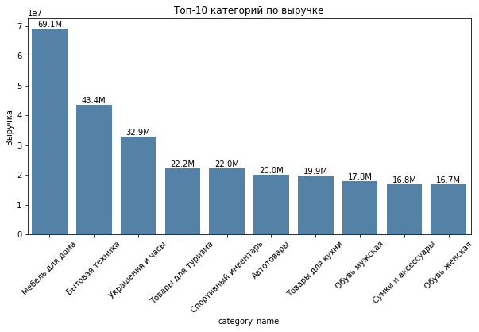

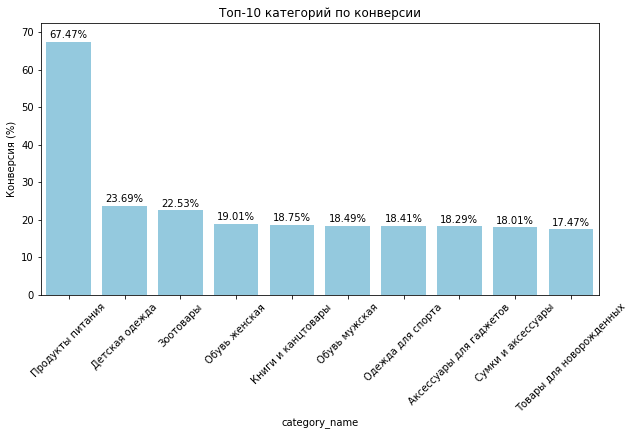

```python
# Построим график выручки
plt.figure(figsize=(10, 5))
top_rev = total_category_rev.head(10)
sns.barplot(data=top_rev, x='category_name', y='revenue', color='steelblue')

# Добавляем подписи
for i, val in enumerate(top_rev['revenue']):
    plt.text(i, val, f'{val/1e6:.1f}M', ha='center', va='bottom', fontsize=10)

plt.title('Топ-10 категорий по выручке')
plt.xticks(rotation=45)
plt.ylabel('Выручка')
plt.show()

# Построим график конверсии
plt.figure(figsize=(10, 5))
top_conv = total_category_conv.head(10)
sns.barplot(data=top_conv, x='category_name', y='conversion_%', color='skyblue')

# Добавляем подписи
for i, val in enumerate(top_conv['conversion_%']):
    plt.text(i, val + 0.5, f'{val}%', ha='center', va='bottom', fontsize=10)

plt.title('Топ-10 категорий по конверсии')
plt.xticks(rotation=45)
plt.ylim(0, top_conv['conversion_%'].max() + 5)
plt.ylabel('Конверсия (%)')
plt.show()
```

На основе полученных данных можно выделить следующие ключевые закономерности:

- Основной объем доходов маркетплейса формируют категории `Мебель для дома` (почти 70 млн) и `Бытовая техника` (около 43 млн). При этом их конверсия находится на среднем уровне 13.23% и 14.21% соответственно.
- Категория `Продукты питания` демонстрирует рекордную конверсию (67.47%). Несмотря на то, что она не входит в топ по выручке, это самый эффективный сегмент с точки зрения завершения сделки.
- Категории `Детская одежда` (23.69%) и `Зоотовары` (22.53%) показывают конверсию выше среднего при умеренной выручке. Это указывает на высокую лояльность или понятную ценность товара для покупателя в этих нишах.
- Категории `Украшения и часы` и `Товары для туризма` генерируют значительную выручку (33 млн и 22 млн), но имеют относительно невысокую конверсию - около 12.7%. Незначительное увеличение CR в этих сегментах может дать существенный прирост в выручке.

**Вывод по анализу воронки:**

Общая статистика показывает, что у маркетплейса есть лидеры:

- По выручке: `Мебель для дома` и `Бытовая техника`. Это категории с высоким чеком.
- По востребованности `Продукты питания` с конверсией 67%. Также популярны `Детская одежда` и `Зоотовары` (конверсия 23–24%).

Структура продаж маркетплейса сбалансирована:

- Дорогие категории (`Мебель`, `Техника`) обеспечивают объем выручки.
- Повседневные категории (`Продукты`, `Детские товары`) обеспечивают высокую оборачиваемость и частоту заказов.

### 4.7 Ключевые результаты анализа

Проведенное исследование выявило, что общее падение эффективности маркетплейса во втором полугодии не связано с техническими сбоями, региональными проблемами или качеством ассортимента. Основная причина - изменение структуры входящего трафика в пользу нерентабельного сегмента.

**Маркетинговая эффективность и каналы**

- Канал `TikTok` стал лидером по объему трафика, но является убыточным (ROI ~ -90%). Его конверсия (8-10%) в 5 раз ниже, чем у `Affiliate` или `Google Ads`.
- Каналы `Affiliate`, `SEO` и `Social Media` показывают стабильно высокую конверсию (45-55%) и положительный ROI. Оптимизация бюджета в их пользу - кратчайший путь к исправлению ситуации.
- ARPPU пользователей из всех каналов (включая `TikTok`) схож. Это доказывает, что продукт интересен всем группам, но воронка привлечения в `TikTok` настроена на нецелевую аудиторию.

**Сегментация и поведение пользователей**

- 70% всей выручки генерируют постоянные клиенты. Сегмент `Regular` приносит в 2-2.5 раза больше дохода с транзакции (ARPPU 2000-2500), чем разовые покупатели.
- Массовый приток пользователей из `TikTok` не конвертируется в покупки, что ухудшает общие показатели CR.
- Анализ по устройствам (`iOS`, `Android`, `Windows`) и регионам показал синхронное изменение метрик. Это подтверждает, что продукт технически исправен, а логистика работает без локальных сбоев.

**Узкие места воронки продаж**

- Обнаружен критический спад на этапе оплаты. Только 64.2% пользователей, завершивших оформление, фактически оплачивают заказ.
- В канале `TikTok` до оплаты доходит лишь 27% пользователей (против 73% в других каналах). Это указывает на импульсивное поведение аудитории, которая имитирует интерес, но не совершает покупку.

**Товарная сегментация**

- `Мебель для дома` и `Бытовая техника` приносят основной объем выручки (~110 млн).
- `Продукты питания` (CR 67%), `Детская одежда` и `Зоотовар` (CR ~23%) - категории с самой высокой лояльностью.

#### Гипотезы по развитию продукта

На основе выявленных закономерностей и взаимосвязи метрик предлагаются следующие гипотезы:

**1. Гипотеза об оптимизации маркетингового сплита:**

Если перераспределить 50% рекламного бюджета из TikTok в пользу `Affiliate` и `Google Ad`, то общая чистая прибыль вырастет, несмотря на возможное снижение общего трафика (MAU).

**Обоснование:**

Текущий ROI `TikTok` (-90%) и высокая конверсия `Affiliate` (55%) гарантируют математический прирост прибыли при замене некачественного трафика качественным.

**2. Гипотеза о внедрении инструментов удержания для `TikTok`:**

Если внедрить механику напоминаний в браузере для трафика из `TikTok`, конверсия из чекаута в оплату вырастет с 27% до 35%.

**Обоснование:**

Высокий показатель checkout_complete в `TikTok` говорит о наличии первичного импульса, который затухает на этапе оплаты.

**3. Гипотеза о масштабировании категории `Продукты питания`:**

Если использовать товары категории `Продукты` (CR 67%) в качестве магнита в рекламных кампаниях, это снизит стоимость привлечения качественного пользователя для всего маркетплейса.

**Обоснование:**

Опираясь на рекордную конверсию категории, мы можем привлекать лояльную аудиторию с высоким потенциалом возврата.

## 5 Подготовка эксперимента и подведение его результатов

Команда продукта рассмотрела гипотезы и на основании этого решила влиять на конверсию при помощи финансовых стимуляций. Так как ситуация со снижением выручки срочная и безотлагательная, пока я продолжала изучать данные, продуктовая команда подключили другого аналитика для подготовки дизайн документа. Проведем эксперимент.

### Новые данные:

```
pa_marketplace_events_AB = pd.read_csv('https://code.s3.yandex.net/datasets/pa_marketplace_events_AB.csv')
pa_marketplace_orders_AB = pd.read_csv('https://code.s3.yandex.net/datasets/pa_marketplace_orders_AB.csv')
pa_marketplace_users_AB = pd.read_csv('https://code.s3.yandex.net/datasets/pa_marketplace_users_AB.csv')
```

**Результаты сплита лежат в таблице:**

```
pa_marketplace_AB_split_users = pd.read_csv('https://code.s3.yandex.net/datasets/pa_marketplace_AB_split_users.csv')
```

- `user_id` – id клиента
- `group` – группа, в которую попал клиент

### Дизайн эксперимента: Бонус на первую покупку для пользователей TikTok

#### 1. Контекст и цель эксперимента

- **Бизнес-контекст:** Команда продукта запускает эксперимент, направленный на повышение конверсии среди пользователей, привлечённых через канал `TikTok`. Для стимулирования первой покупки пользователям будет предоставлен бонус на первую покупку.
- **Цель:** Проверить, влияет ли предоставление бонуса на первую покупку на конверсию и выручку среди пользователей `TikTok`.
- **Гипотеза:** Предоставление бонуса на первую покупку новым пользователям, привлеченным через `TikTok`, приведет к увеличению конверсии в первую покупку

#### 2. Формат эксперимента

- **Тип эксперимента:** Сплит-роллинг (rolling split)
- **Канал:** Только пользователи, пришедшие с `TikTok`
- **Группы:**
  - **Контрольная (A):** пользователи `TikTok` без бонуса
  - **Тестовая (B):** пользователи `TikTok` с бонусом на первую покупку
- **Распределение:** Равномерное распределение новых пользователей `TikTok` между группами по дате регистрации
- **Период проведения:** 3 недели (фиксировано)

#### 3. Ключевые метрики

##### Основная метрика

- **Конверсия в первую покупку** — доля пользователей, зарегистрировавшихся с TikTok и совершивших первую покупку
- *Цель:* увеличить конверсию с помощью бонуса
- *Критерий успеха:* статистически значимый рост конверсии в тестовой группе

##### Вспомогательные метрики

- **ARPU** (средняя выручка на пользователя TikTok)
- **ARPPU** (средняя выручка на покупателя TikTok)
- **AOV** (средний чек TikTok)

##### Барьерная метрика

## - **Общая выручка от пользователей TikTok**

#### 4. Размеры групп и запуск

- **Целевая аудитория:** только пользователи TikTok
- **Размеры групп:** определяются по фактическому трафику TikTok за период эксперимента
- **Комментарий:** запуск без предварительного расчёта мощности и MDE из-за срочности задачи

### 5.1 Анализ аудитории эксперимента

Загрузим данные с результатами эксперимента. Проверим корректность данных и проведем предобработку.

- Начнем с **данных пользователей** эксперимента.

```python
# Выгружаем данные пользователей A/B-эксперимента
pa_marketplace_users_AB = pd.read_csv('https://code.s3.yandex.net/datasets/pa_marketplace_users_AB.csv',
                                     parse_dates=['registration_date', 'cohort_week', 'cohort_month'])

display(pa_marketplace_users_AB.head())
print()
pa_marketplace_users_AB.info()
```

|  | user_id | registration_date | age | gender | region | acq_channel | buyer_segment | cohort_week | cohort_month |
| --- | --- | --- | --- | --- | --- | --- | --- | --- | --- |
| 0 | 18 | 2024-01-01 05:26:00 | 49 | M | Екатеринбург | TikTok | one_time | 2024-01-01 | 2024-01-01 |
| 1 | 22 | 2024-01-01 17:13:00 | 50 | M | Санкт-Петербург | TikTok | one_time | 2024-01-01 | 2024-01-01 |
| 2 | 26 | 2024-01-01 21:15:00 | 60 | F | Москва | TikTok | rare | 2024-01-01 | 2024-01-01 |
| 3 | 33 | 2024-01-01 14:43:00 | 31 | M | Екатеринбург | TikTok | rare | 2024-01-01 | 2024-01-01 |
| 4 | 39 | 2024-01-01 01:13:00 | 44 | M | Санкт-Петербург | TikTok | rare | 2024-01-01 | 2024-01-01 |

```
<class 'pandas.core.frame.DataFrame'>
RangeIndex: 22196 entries, 0 to 22195
Data columns (total 9 columns):
 #   Column             Non-Null Count  Dtype
---  ------             --------------  -----
 0   user_id            22196 non-null  int64
 1   registration_date  22196 non-null  datetime64[ns]
 2   age                22196 non-null  int64
 3   gender             22196 non-null  object
 4   region             22196 non-null  object
 5   acq_channel        22196 non-null  object
 6   buyer_segment      22196 non-null  object
 7   cohort_week        22196 non-null  datetime64[ns]
 8   cohort_month       22196 non-null  datetime64[ns]
dtypes: datetime64[ns](3), int64(2), object(4)
memory usage: 1.5+ MB
```

- Данные представлены корректными типами данных, пропуски отсутствуют.

```python
# Выводим количество уникальных значений в колонке user_id и значения в region, acq_channel, buyer_segment
print(f"Количество уникальных значений user_id - {pa_marketplace_users_AB['user_id'].nunique()}.")

summary_users_AB = (
    pa_marketplace_users_AB[['region', 'acq_channel','buyer_segment']]
    .apply(lambda x: ", ".join(sorted(x.dropna().unique())))
    .reset_index()
)

summary_users_AB.columns = ['column', 'unique_values']
pd.set_option('display.max_colwidth', None)
display(summary_users_AB)
```

```
Количество уникальных значений user_id - 22196.
```

|  | column | unique_values |
| --- | --- | --- |
| 0 | region | Другие регионы, Екатеринбург, Краснодар, Москва, Московская область, Нижний Новгород, Новосибирск, Ростов-на-Дону, Санкт-Петербург |
| 1 | acq_channel | TikTok |
| 2 | buyer_segment | medium, one_time, rare, regular |

- В датасете представлены все ключевые признаки: регион, канал привлечения `TikTok` и сегмент покупателей.

```python
# Выгружаем данные сплитования A/B-эксперимента
pa_marketplace_AB_split_users = pd.read_csv('https://code.s3.yandex.net/datasets/pa_marketplace_AB_split_users.csv')

display(pa_marketplace_AB_split_users.head())
print()
pa_marketplace_AB_split_users.info()
```

|  | user_id | group |
| --- | --- | --- |
| 0 | 44965 | control |
| 1 | 44967 | control |
| 2 | 44968 | control |
| 3 | 44969 | treatment |
| 4 | 44970 | control |

```
<class 'pandas.core.frame.DataFrame'>
RangeIndex: 2968 entries, 0 to 2967
Data columns (total 2 columns):
 #   Column   Non-Null Count  Dtype
---  ------   --------------  -----
 0   user_id  2968 non-null   int64
 1   group    2968 non-null   object
dtypes: int64(1), object(1)
memory usage: 46.5+ KB
```

```python
# Добавим к таблице пользователей  группу A/B-эксперимента
df_users_AB = pa_marketplace_users_AB.merge(pa_marketplace_AB_split_users, on='user_id')

df_users_AB.info()
```

```
<class 'pandas.core.frame.DataFrame'>
Int64Index: 2968 entries, 0 to 2967
Data columns (total 10 columns):
 #   Column             Non-Null Count  Dtype
---  ------             --------------  -----
 0   user_id            2968 non-null   int64
 1   registration_date  2968 non-null   datetime64[ns]
 2   age                2968 non-null   int64
 3   gender             2968 non-null   object
 4   region             2968 non-null   object
 5   acq_channel        2968 non-null   object
 6   buyer_segment      2968 non-null   object
 7   cohort_week        2968 non-null   datetime64[ns]
 8   cohort_month       2968 non-null   datetime64[ns]
 9   group              2968 non-null   object
dtypes: datetime64[ns](3), int64(2), object(5)
memory usage: 255.1+ KB
```

```python
# Проверяем корректность сплита
summary_groups_AB = (
    df_users_AB
    .groupby('group', as_index=False)
    .agg(users_count=('user_id', 'nunique'))
)

summary_groups_AB['users_share'] = round(summary_groups_AB['users_count'] / summary_groups_AB['users_count'].sum(), 2)

display(summary_groups_AB)
```

|  | group | users_count | users_share |
| --- | --- | --- | --- |
| 0 | control | 1503 | 0.51 |
| 1 | treatment | 1465 | 0.49 |

```python
# Считаем количество уникальных групп на user_id
flawed_users = df_users_AB.groupby('user_id')['group'].nunique().reset_index()

# Фильтруем клиентов у которых больше 1 группы
flawed_users = flawed_users[flawed_users['group'] > 1]

print(f'Количество пользователей, попавших сразу в две группы: {len(flawed_users)}.')
```

```
Количество пользователей, попавших сразу в две группы: 0.
```

```python
# Проверим интервал дат регистраций
start_date_abt = df_users_AB['registration_date'].min()
end_date_abt = df_users_AB['registration_date'].max()

print(f'Период данных: с {start_date_abt} по {end_date_abt}')
```

```
Период данных: с 2025-01-01 00:05:00 по 2025-01-26 23:41:00
```

```python
# Количество полных дубликатов
full_duplicates_abt = df_users_AB.duplicated().sum()
print(f'Количество полных дубликатов строк: {full_duplicates_abt}')
```

```
Количество полных дубликатов строк: 0
```

```python
# Проверим дубликаты по комбинации ключевых полей
key_duplicates_abt = (
    df_users_AB
    .duplicated(subset=['user_id', 'registration_date', 'acq_channel'])
    .sum()
)

print(f'Неявные дубликаты событий: {key_duplicates_abt}')
```

```
Неявные дубликаты событий: 0
```

```python
# Проверка корректности аудитории
df_users_AB['acq_channel'].value_counts()
```

```
TikTok    2968
Name: acq_channel, dtype: int64
```

```python
# Проверка сегмента новых покупателей
df_users_AB['buyer_segment'].value_counts()
```

```
medium      1069
rare         887
regular      551
one_time     461
Name: buyer_segment, dtype: int64
```

В рамках подготовки к анализу A/B-эксперимента были загружены и объединены данные о пользователях, привлечённых через канал `TikTok`, а также информация об их распределении по экспериментальным группам. После объединения таблиц была сформирована выборка участников эксперимента, включающая 2 968 уникальных пользователей без пропусков и дубликатов.

Проверка корректности сплита показала, что пользователи распределены между контрольной и тестовой группами равномерно (≈50/50), пересечений пользователей между группами не обнаружено. Период регистрации участников соответствует заявленному окну проведения эксперимента (01.01.2025 - 26.01.2025), что подтверждает корректность временных границ выборки. Также подтверждено, что все участники эксперимента были привлечены исключительно через канал `TikTok`, что соответствует условиям дизайна.

Однако дополнительная проверка сегмента покупателей показала, что в выборке присутствуют пользователи разных поведенческих сегментов (`one_time`, `rare`, `medium`, `regular`), тогда как по дизайну эксперимента бонус должен предоставляться только новым пользователям, совершающим первую покупку. Это указывает на потенциальное несоответствие фактической аудитории условиям эксперимента, которое может привести к искажению оценки эффекта бонуса на конверсию.

Таким образом, несмотря на корректность технического сплита и качество данных, выявленное несоответствие состава аудитории требует дополнительной проверки бизнес-логики эксперимента или последующей фильтрации пользователей перед расчётом метрик. Дальнейший анализ результатов A/B-теста следует проводить с учётом данного ограничения.

- Загрузим и рассмотрим **данные о событиях пользователей.**

```python
# Выгружаем данные событий A/B-эксперимента
pa_marketplace_events_AB = pd.read_csv('https://code.s3.yandex.net/datasets/pa_marketplace_events_AB.csv',
                                       parse_dates=['event_date', 'event_week', 'event_month'])

display(pa_marketplace_events_AB.head())
print()
pa_marketplace_events_AB.info()
```

|  | event_id | user_id | event_date | event_type | os | device | product_name | event_week | event_month |
| --- | --- | --- | --- | --- | --- | --- | --- | --- | --- |
| 0 | 3132 | 100 | 2024-01-01 15:23:56 | page_view | iOS | mobile | NaN | 2024-01-01 | 2024-01-01 |
| 1 | 3133 | 100 | 2024-01-01 15:24:01 | product_view | iOS | mobile | Шорты для тренировок | 2024-01-01 | 2024-01-01 |
| 2 | 3134 | 100 | 2024-01-01 15:24:10 | product_click | iOS | mobile | Куртка детская | 2024-01-01 | 2024-01-01 |
| 3 | 3135 | 100 | 2024-01-01 15:25:10 | add_to_cart | iOS | mobile | Балетки классические | 2024-01-01 | 2024-01-01 |
| 4 | 3136 | 100 | 2024-01-01 15:25:46 | checkout_start | iOS | mobile | NaN | 2024-01-01 | 2024-01-01 |

```
<class 'pandas.core.frame.DataFrame'>
RangeIndex: 831231 entries, 0 to 831230
Data columns (total 9 columns):
 #   Column        Non-Null Count   Dtype
---  ------        --------------   -----
 0   event_id      831231 non-null  int64
 1   user_id       831231 non-null  int64
 2   event_date    831231 non-null  datetime64[ns]
 3   event_type    831231 non-null  object
 4   os            831231 non-null  object
 5   device        831231 non-null  object
 6   product_name  409054 non-null  object
 7   event_week    831231 non-null  datetime64[ns]
 8   event_month   831231 non-null  datetime64[ns]
dtypes: datetime64[ns](3), int64(2), object(4)
memory usage: 57.1+ MB
```

- Данные представлены корректными типами данных.

```python
# Отфильтруем таблицу событий по пользователям А/B-эксперимента
df_events_AB = pa_marketplace_events_AB.merge(df_users_AB[['user_id', 'registration_date', 'group']], on='user_id')

df_events_AB.info()
```

```
<class 'pandas.core.frame.DataFrame'>
Int64Index: 4349 entries, 0 to 4348
Data columns (total 11 columns):
 #   Column             Non-Null Count  Dtype
---  ------             --------------  -----
 0   event_id           4349 non-null   int64
 1   user_id            4349 non-null   int64
 2   event_date         4349 non-null   datetime64[ns]
 3   event_type         4349 non-null   object
 4   os                 4349 non-null   object
 5   device             4349 non-null   object
 6   product_name       2335 non-null   object
 7   event_week         4349 non-null   datetime64[ns]
 8   event_month        4349 non-null   datetime64[ns]
 9   registration_date  4349 non-null   datetime64[ns]
 10  group              4349 non-null   object
dtypes: datetime64[ns](4), int64(2), object(5)
memory usage: 407.7+ KB
```

```python
# Выводим количество уникальных значений в колонке event_id, user_id, product_name и значения в event_type, os, device
print(f"Количество уникальных значений event_id - {df_events_AB['event_id'].nunique()}.")
print(f"Количество уникальных значений user_id - {df_events_AB['user_id'].nunique()}.")
print(f"Количество уникальных значений product_name - {df_events_AB['product_name'].nunique()}.")

summary_events_abt = (
    df_events_AB[['event_type', 'os', 'device']]
    .apply(lambda x: ", ".join(sorted(x.dropna().unique())))
    .reset_index()
)

summary_events_abt.columns = ['column', 'unique_values']
pd.set_option('display.max_colwidth', None)
display(summary_events_abt)
```

```
Количество уникальных значений event_id - 4349.
Количество уникальных значений user_id - 499.
Количество уникальных значений product_name - 200.
```

|  | column | unique_values |
| --- | --- | --- |
| 0 | event_type | add_to_cart, banner_click, category_view, checkout_complete, checkout_start, filter_apply, page_view, product_click, product_view, promo_view, remove_from_cart, search, user_login, user_logout, wishli… |
| 1 | os | Android, Windows, iOS, macOS |
| 2 | device | desktop, mobile, tablet |

```python
# Проверим интервал дат событий
start_date_events_abt = df_events_AB['event_date'].min()
end_date_events_abt = df_events_AB['event_date'].max()

print(f'Период данных: с {start_date_events_abt} по {end_date_events_abt}')
```

```
Период данных: с 2025-01-02 03:25:32 по 2025-01-26 23:46:15
```

```python
# Количество полных дубликатов
full_duplicates_events_abt = df_events_AB.duplicated().sum()
print(f'Количество полных дубликатов строк: {full_duplicates_events_abt}')
```

```
Количество полных дубликатов строк: 0
```

```python
# Проверим доли пользователей без событий
users_total = pa_marketplace_AB_split_users['user_id'].nunique()
users_with_events = df_events_AB['user_id'].nunique()

print('Пользователей в эксперименте:', users_total)
print('Пользователей с событиями:', users_with_events)
print('Доля пользователей без событий:',
      round(1 - users_with_events / users_total, 3))
```

```
Пользователей в эксперименте: 2968
Пользователей с событиями: 499
Доля пользователей без событий: 0.832
```

```python
# Проверка активности по группам
activity_by_group = (
    df_events_AB.groupby('group')['user_id']
    .nunique()
    .reset_index(name='active_users')
)

activity_by_group['share'] = round(
    activity_by_group['active_users']
    / activity_by_group['active_users'].sum() * 100, 2)

display(activity_by_group)
```

|  | group | active_users | share |
| --- | --- | --- | --- |
| 0 | control | 261 | 52.3 |
| 1 | treatment | 238 | 47.7 |

```python
# Проверка распределения типов событий по группам
event_dist = pd.crosstab(
    df_events_AB['event_type'],
    df_events_AB['group'],
    normalize='columns'
)

display(event_dist.round(2))
```

| group event_type | control | treatment |
| --- | --- | --- |
| add_to_cart | 0.14 | 0.14 |
| banner_click | 0.03 | 0.02 |
| category_view | 0.02 | 0.02 |
| checkout_complete | 0.04 | 0.06 |
| checkout_start | 0.07 | 0.09 |
| filter_apply | 0.02 | 0.01 |
| page_view | 0.19 | 0.18 |
| product_click | 0.18 | 0.17 |
| product_view | 0.19 | 0.18 |
| promo_view | 0.01 | 0.02 |
| remove_from_cart | 0.02 | 0.02 |
| search | 0.02 | 0.03 |
| user_login | 0.02 | 0.02 |
| user_logout | 0.03 | 0.02 |
| wishlist_add | 0.02 | 0.02 |

```python
# Проверка OS по группам
activity_by_os = (
    df_events_AB.groupby(['group', 'os'])['user_id']
    .nunique()
    .reset_index(name='active_users')
)

activity_by_os['share'] = round(
    activity_by_os['active_users']
    / activity_by_os['active_users'].sum() * 100, 2)

display(activity_by_os)
```

|  | group | os | active_users | share |
| --- | --- | --- | --- | --- |
| 0 | control | Android | 59 | 11.82 |
| 1 | control | Windows | 70 | 14.03 |
| 2 | control | iOS | 70 | 14.03 |
| 3 | control | macOS | 62 | 12.42 |
| 4 | treatment | Android | 54 | 10.82 |
| 5 | treatment | Windows | 56 | 11.22 |
| 6 | treatment | iOS | 58 | 11.62 |
| 7 | treatment | macOS | 70 | 14.03 |

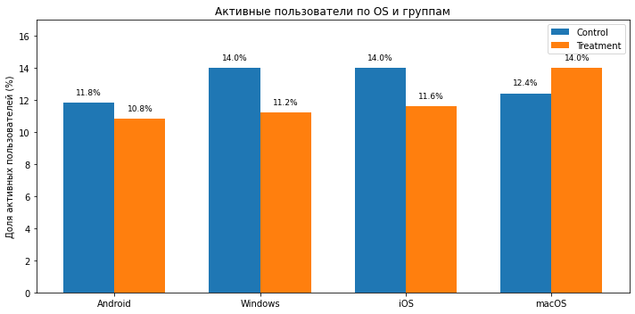

```python
# Берем только нужные колонки и группируем по OS
plot_df = activity_by_os.pivot(index='os', columns='group', values='share').round(2)

x = np.arange(len(plot_df.index))
width = 0.35

plt.figure(figsize=(10, 5))

# Столбцы для каждой группы
plt.bar(x - width/2, plot_df['control'], width, label='Control')
plt.bar(x + width/2, plot_df['treatment'], width, label='Treatment')

# Подписи сверху
for i, val in enumerate(plot_df['control']):
    plt.text(i - width/2, val + 0.5, f'{val:.1f}%', ha='center', fontsize=9)
for i, val in enumerate(plot_df['treatment']):
    plt.text(i + width/2, val + 0.5, f'{val:.1f}%', ha='center', fontsize=9)

plt.xticks(x, plot_df.index)
plt.ylabel('Доля активных пользователей (%)')
plt.title('Активные пользователи по OS и группам')
plt.ylim(0, 17)
plt.legend()
plt.tight_layout()
plt.show()
```

```python
# Проверка типов устройств по группам
activity_by_device = (
    df_events_AB.groupby(['group', 'device'])['user_id']
    .nunique()
    .reset_index(name='active_users')
)

activity_by_device['share'] = round(
    activity_by_device['active_users']
    / activity_by_device['active_users'].sum() * 100, 2)

display(activity_by_device)
```

|  | group | device | active_users | share |
| --- | --- | --- | --- | --- |
| 0 | control | desktop | 80 | 16.03 |
| 1 | control | mobile | 85 | 17.03 |
| 2 | control | tablet | 96 | 19.24 |
| 3 | treatment | desktop | 89 | 17.84 |
| 4 | treatment | mobile | 60 | 12.02 |
| 5 | treatment | tablet | 89 | 17.84 |

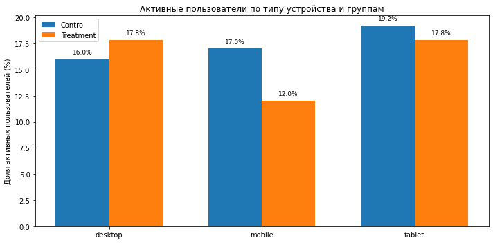

```python
# Поворот таблицы для удобства построения
plot_df = activity_by_device.pivot(index='device', columns='group', values='share').round(2)

x = np.arange(len(plot_df.index))
width = 0.35

plt.figure(figsize=(10, 5))
plt.bar(x - width/2, plot_df['control'], width, label='Control')
plt.bar(x + width/2, plot_df['treatment'], width, label='Treatment')

for i, val in enumerate(plot_df['control']):
    plt.text(i - width/2, val + 0.5, f'{val:.1f}%', ha='center', fontsize=9)
for i, val in enumerate(plot_df['treatment']):
    plt.text(i + width/2, val + 0.5, f'{val:.1f}%', ha='center', fontsize=9)

plt.xticks(x, plot_df.index)
plt.ylabel('Доля активных пользователей (%)')
plt.title('Активные пользователи по типу устройства и группам')
plt.legend()
plt.tight_layout()
plt.show()
```

```python
# Проверим есть ли события до регистрации
events_before_reg = df_events_AB[
    df_events_AB['event_date'] < df_events_AB['registration_date']
]

print('Событий до регистрации:', len(events_before_reg))
```

```
Событий до регистрации: 8
```

```python
# Удаляем события до регистрации
df_events_AB = df_events_AB[df_events_AB['event_date'] >= df_events_AB['registration_date']]

# Проверим, что все корректно
print('Строк после удаления событий до регистрации:', len(df_events_AB))
```

```
Строк после удаления событий до регистрации: 4341
```

- В результате объединения логов событий с таблицей участников A/B-эксперимента была получена выборка из 4 341 события, относящихся к 499 уникальным пользователям из 2 968 участников эксперимента.
- Было обнаружено 8 событий, произошедших до даты регистрации, которые были удалены из анализа, чтобы корректно оценивать поведение пользователей после вступления в эксперимент.
- Доля пользователей без зафиксированной активности остаётся высокой: ≈83 %, что указывает на низкое покрытие событийными данными.
- Распределение активных пользователей между контрольной и тестовой группами близко к равномерному (52 % и 48 %), а структура типов событий, операционных систем и устройств не демонстрирует существенных перекосов между группами. Это свидетельствует о технически корректном сплите среди активной аудитории.
- Основным ограничением данных является низкая доля активных пользователей, что снижает статистическую мощность эксперимента и может затруднить выявление значимого эффекта бонуса. 83% пользователей вообще не имеют событий, а занчит: они не видели продукт, не могли получить бонус, не могли совершить покупку. Следовательно метрика конверсии будет почти нулевая, статистической мощности не хватит.
- Загрузим и рассмотрим **данные о заказах пользователей.**

```python
# Выгружаем данные заказов A/B-эксперимента
pa_marketplace_orders_AB = pd.read_csv('https://code.s3.yandex.net/datasets/pa_marketplace_orders_AB.csv',
                                      parse_dates=['order_date', 'order_week', 'order_month'])

display(pa_marketplace_orders_AB.head())
print()
pa_marketplace_orders_AB.info()
```

|  | order_id | user_id | order_date | product_name | quantity | unit_price | total_price | category_name | order_week | order_month |
| --- | --- | --- | --- | --- | --- | --- | --- | --- | --- | --- |
| 0 | 1 | 3 | 2024-01-19 01:52:52 | Шуруповерт | 2 | 5539.13 | 11078.26 | Инструменты и садовый инвентарь | 2024-01-15 | 2024-01-01 |
| 1 | 2 | 3 | 2024-01-19 01:52:52 | Молоток слесарный | 1 | 11340.38 | 11340.38 | Инструменты и садовый инвентарь | 2024-01-15 | 2024-01-01 |
| 2 | 3 | 3 | 2024-01-19 01:52:52 | Секатор садовый | 2 | 10892.09 | 21784.18 | Инструменты и садовый инвентарь | 2024-01-15 | 2024-01-01 |
| 3 | 4 | 3 | 2024-01-25 13:59:38 | Шуруповерт | 2 | 5539.13 | 11078.26 | Инструменты и садовый инвентарь | 2024-01-22 | 2024-01-01 |
| 4 | 5 | 3 | 2024-01-25 13:59:38 | Чай черный | 1 | 2099.59 | 2099.59 | Продукты питания | 2024-01-22 | 2024-01-01 |

```
<class 'pandas.core.frame.DataFrame'>
RangeIndex: 33280 entries, 0 to 33279
Data columns (total 10 columns):
 #   Column         Non-Null Count  Dtype
---  ------         --------------  -----
 0   order_id       33280 non-null  int64
 1   user_id        33280 non-null  int64
 2   order_date     33280 non-null  datetime64[ns]
 3   product_name   33280 non-null  object
 4   quantity       33280 non-null  int64
 5   unit_price     33280 non-null  float64
 6   total_price    33280 non-null  float64
 7   category_name  33280 non-null  object
 8   order_week     33280 non-null  datetime64[ns]
 9   order_month    33280 non-null  datetime64[ns]
dtypes: datetime64[ns](3), float64(2), int64(3), object(2)
memory usage: 2.5+ MB
```

```python
# Отфильтруем таблицу событий по пользователям А/B-эксперимента
df_orders_AB = pa_marketplace_orders_AB.merge(df_users_AB[['user_id', 'registration_date', 'group']], on='user_id')

df_orders_AB.info()
```

```
<class 'pandas.core.frame.DataFrame'>
Int64Index: 255 entries, 0 to 254
Data columns (total 12 columns):
 #   Column             Non-Null Count  Dtype
---  ------             --------------  -----
 0   order_id           255 non-null    int64
 1   user_id            255 non-null    int64
 2   order_date         255 non-null    datetime64[ns]
 3   product_name       255 non-null    object
 4   quantity           255 non-null    int64
 5   unit_price         255 non-null    float64
 6   total_price        255 non-null    float64
 7   category_name      255 non-null    object
 8   order_week         255 non-null    datetime64[ns]
 9   order_month        255 non-null    datetime64[ns]
 10  registration_date  255 non-null    datetime64[ns]
 11  group              255 non-null    object
dtypes: datetime64[ns](4), float64(2), int64(3), object(3)
memory usage: 25.9+ KB
```

```python
# Выводим количество уникальных значений в колонке event_id, user_id, product_name и значения в category_name
print(f"Количество уникальных значений order_id - {df_orders_AB['order_id'].nunique()}.")
print(f"Количество уникальных значений user_id - {df_orders_AB['user_id'].nunique()}.")
print(f"Количество уникальных значений product_name - {df_orders_AB['product_name'].nunique()}.")
print(f"Количество уникальных значений category_name - {df_orders_AB['category_name'].nunique()}.")
```

```
Количество уникальных значений order_id - 255.
Количество уникальных значений user_id - 126.
Количество уникальных значений product_name - 141.
Количество уникальных значений category_name - 25.
```

```python
# Проверим интервал дат событий
start_date_orders_abt = df_orders_AB['order_date'].min()
end_date_orders_abt = df_orders_AB['order_date'].max()

print(f'Период данных: с {start_date_orders_abt} по {end_date_orders_abt}')
```

```
Период данных: с 2025-01-01 11:57:43 по 2025-01-26 20:39:35
```

```python
# Количество полных дубликатов
full_duplicates_orders_abt = df_orders_AB.duplicated().sum()
print(f'Количество полных дубликатов строк: {full_duplicates_orders_abt}')
```

```
Количество полных дубликатов строк: 0
```

```python
# Проверим дубликаты по комбинации ключевых полей
key_duplicates_orders_abt = (
    df_orders_AB
    .duplicated(subset=['user_id', 'order_date', 'product_name', 'quantity', 'unit_price', 'total_price'])
    .sum()
)

print(f'Неявные дубликаты событий: {key_duplicates_orders_abt}')
```

```
Неявные дубликаты событий: 2
```

```python
# Выгрузим строки с неявными дубликатами по ключевым полям
duplicate_orders_rows_abt = df_orders_AB[
    df_orders_AB.duplicated(
        subset=['user_id', 'order_date', 'product_name', 'quantity', 'unit_price', 'total_price'],
        keep=False
    )
]

display(duplicate_orders_rows_abt)
```

|  | order_id | user_id | order_date | product_name | quantity | unit_price | total_price | category_name | order_week | order_month | registration_date | group |
| --- | --- | --- | --- | --- | --- | --- | --- | --- | --- | --- | --- | --- |
| 18 | 37485 | 45910 | 2025-01-07 10:08:22 | Маска для волос | 1 | 1243.98 | 1243.98 | Косметика и парфюмерия | 2025-01-06 | 2025-01-01 | 2025-01-06 00:56:00 | treatment |
| 19 | 37484 | 45910 | 2025-01-07 10:08:22 | Маска для волос | 1 | 1243.98 | 1243.98 | Косметика и парфюмерия | 2025-01-06 | 2025-01-01 | 2025-01-06 00:56:00 | treatment |
| 239 | 38412 | 47663 | 2025-01-25 21:12:00 | Джинсы Levi's | 1 | 7024.59 | 7024.59 | Мужская одежда | 2025-01-20 | 2025-01-01 | 2025-01-18 21:12:00 | treatment |
| 240 | 38413 | 47663 | 2025-01-25 21:12:00 | Джинсы Levi's | 1 | 7024.59 | 7024.59 | Мужская одежда | 2025-01-20 | 2025-01-01 | 2025-01-18 21:12:00 | treatment |

- Каждая пара дубликатов имеет одинаковое время в точности до секунд и одниковую стоимость в точности до копеек, что похоже на техническую ошибку при загрузке или синхронизации данных. Удалим эти дубликаты, чтобы они не искажали результаты.

```python
# Удалим дубликаты
df_orders_AB = (
    df_orders_AB.drop_duplicates(
    subset=['user_id', 'order_date', 'product_name', 'quantity', 'unit_price', 'total_price']
))

print(f'Количество строк df_orders_AB: {len(df_orders_AB)}')
```

```
Количество строк df_orders_AB: 253
```

```python
# Проверим наличие заказов до регистрации
orders_before_reg = df_orders_AB[
    df_orders_AB['order_date'] < df_orders_AB['registration_date']
]

print('Заказов до регистрации:', len(orders_before_reg))
```

```
Заказов до регистрации: 0
```

```python
# Проверка покупателей по группам
buyers_by_group = (
    df_orders_AB.groupby('group')['user_id']
    .nunique()
    .reset_index(name='active_users')
)

buyers_by_group['share'] = round(
    buyers_by_group['active_users']
    / buyers_by_group['active_users'].sum() * 100, 2)

display(buyers_by_group)
```

|  | group | active_users | share |
| --- | --- | --- | --- |
| 0 | control | 16 | 12.7 |
| 1 | treatment | 110 | 87.3 |

- После очистки дубликатов и проверки на заказы до регистрации осталось 253 заказа, 126 уникальных пользователей.
- Распределение покупателей по группам очень неравномерное: 16 пользователей в контрольной группе и 110 - в тестовой. Такая дисбалансная выборка существенно снижает доверие к выводам по конверсии и выручке.

**Вывод по анализу сплитования пользователей:**

Проведена предварительная подготовка данных для анализа A/B-эксперимента по бонусу на первую покупку для пользователей TikTok. Объединены данные о пользователях, сплите, событиях и заказах. После удаления технических некорректных записей и событий до регистрации получена чистая выборка.

Технически сплит корректен: нет пересечений между группами, пользователи распределены почти равномерно, дубликаты удалены. Однако выявлены ключевые ограничения: большая часть пользователей не проявляла активности (≈83 %), присутствуют пользователи, которые ранее совершали покупки, а распределение покупателей по группам крайне неравномерное (16 в контроле и 110 в тесте). Эти факторы существенно ограничивают статистическую мощность эксперимента и могут повлиять на точность оценки эффекта бонуса на конверсию и выручку.

### 5.2 Сравнение воронок событий

- Сравним пользовательский путь новых пользователей в тестовой и контрольной группах.
- Построем классическую и последовательную воронки, выполним визуализацию и сделаем промежуточный вывод.

Этапы воронки:

1. Просмотр платформы (`page_view`).
2. Интерес к товару (`product_view`).
3. Намерение купить (`add_to_cart`).
4. Начало оформления (`checkout_start`).
5. Завершение оформления заказа (`checkout_complete`).
6. Оплата (данные по оплате из таблицы `orders_df`).

```python
# Добавляем шаг по оплате (покупка)
funnel_steps_complete = funnel_steps + ['payment']

# Разделим данные по группам
control_events = df_events_AB[df_events_AB['group'] == 'control']
treatment_events = df_events_AB[df_events_AB['group'] == 'treatment']

control_orders = df_orders_AB[df_orders_AB['group'] == 'control']
treatment_orders = df_orders_AB[df_orders_AB['group'] == 'treatment']

# Контрольная группа
# Считаем пользователей на каждом событии
counts_control_events = control_events[control_events['event_type'].isin(funnel_steps)]
counts_control_agg = counts_control_events.groupby('event_type')['user_id'].nunique().reindex(funnel_steps)

# Добавляем шаг по оплате (покупка)
counts_control_agg['payment'] = control_orders['user_id'].nunique()

# Классическая конверсия и step-by-step конверсия
control_funnel_classic = round(counts_control_agg / counts_control_agg.iloc[0] * 100, 2)
control_funnel_step = round(counts_control_agg / counts_control_agg.shift(1) * 100, 2)

# Тестовая группа
counts_treatment_events = treatment_events[treatment_events['event_type'].isin(funnel_steps)]
counts_treatment_agg = counts_treatment_events.groupby('event_type')['user_id'].nunique().reindex(funnel_steps)
counts_treatment_agg['payment'] = treatment_orders['user_id'].nunique()

treatment_funnel_classic = round(counts_treatment_agg / counts_treatment_agg.iloc[0] * 100, 2)
treatment_funnel_step = round(counts_treatment_agg / counts_treatment_agg.shift(1) * 100, 2)

classic_funnel_compare = pd.DataFrame({
    'step': funnel_steps_complete[1:],
    'control': control_funnel_classic[1:].values,
    'treatment': treatment_funnel_classic[1:].values
})

step_funnel_compare = pd.DataFrame({
    'step': funnel_steps_complete[1:],
    'control': control_funnel_step[1:].values,
    'treatment': treatment_funnel_step[1:].values
})

print('Классическая воронка (% пользователей от первого шага):')
display(classic_funnel_compare)

print('\nStep-by-step воронка (% пользователей относительно предыдущего шага):')
display(step_funnel_compare)
```

```
Классическая воронка (% пользователей от первого шага):
```

|  | step | control | treatment |
| --- | --- | --- | --- |
| 0 | product_view | 99.61 | 99.14 |
| 1 | add_to_cart | 81.78 | 83.19 |
| 2 | checkout_start | 48.84 | 55.17 |
| 3 | checkout_complete | 30.62 | 35.78 |
| 4 | payment | 6.20 | 47.41 |

```
Step-by-step воронка (% пользователей относительно предыдущего шага):
```

|  | step | control | treatment |
| --- | --- | --- | --- |
| 0 | product_view | 99.61 | 99.14 |
| 1 | add_to_cart | 82.10 | 83.91 |
| 2 | checkout_start | 59.72 | 66.32 |
| 3 | checkout_complete | 62.70 | 64.84 |
| 4 | payment | 20.25 | 132.53 |

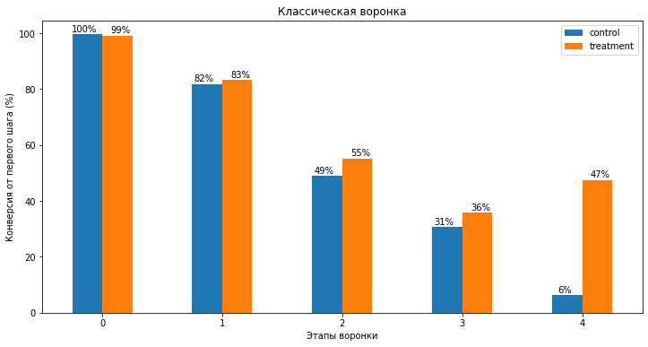

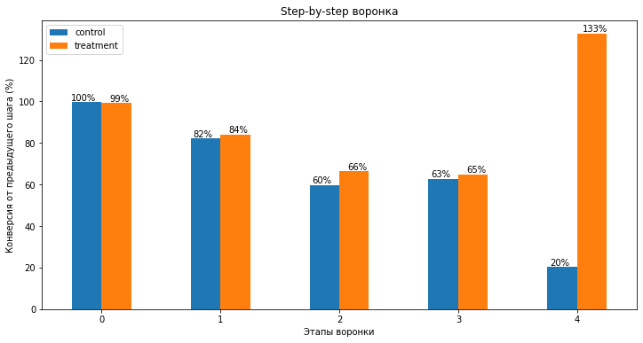

```python
# Визуализируем данные классической воронки

# Строим столбчатую диаграмму
classic_plot_df = classic_funnel_compare[['control', 'treatment']].plot(
    kind='bar',
    figsize=(12, 6),
    legend=True,
    rot=0
)

# Подписи для control
for index, value in enumerate(classic_funnel_compare['control']):
    # Для каждого значения добавляем текст на график
    plt.text(index - 0.15, value + 1, f'{value:.0f}%', ha='center', fontsize=10, color='black')

# Подписи для test
for index, value in enumerate(classic_funnel_compare['treatment']):
    # Для каждого значения добавляем текст на график
    plt.text(index + 0.15, value + 1, f'{value:.0f}%', ha='center', fontsize=10, color='black')

# Настраиваем оформление графика
plt.title('Классическая воронка')
plt.xlabel('Этапы воронки')
plt.ylabel('Конверсия от первого шага (%)')


# Визуализируем данные воронки step-by-step

# Строим столбчатую диаграмму
step_plot_df = step_funnel_compare[['control', 'treatment']].plot(
    kind='bar',
    figsize=(12, 6),
    legend=True,
    rot=0
)

# Подписи для control
for index, value in enumerate(step_funnel_compare['control']):
    # Для каждого значения добавляем текст на график
    plt.text(index - 0.15, value + 1, f'{value:.0f}%', ha='center', fontsize=10, color='black')

# Подписи для test
for index, value in enumerate(step_funnel_compare['treatment']):
    # Для каждого значения добавляем текст на график
    plt.text(index + 0.15, value + 1, f'{value:.0f}%', ha='center', fontsize=10, color='black')

# Настраиваем оформление графика
plt.title('Step-by-step воронка')
plt.xlabel('Этапы воронки')
plt.ylabel('Конверсия от предыдущего шага (%)')
plt.show()
```

```python
users_checkout_complete = set(
    treatment_events[treatment_events['event_type'] == 'checkout_complete']['user_id']
)

users_payment = set(treatment_orders['user_id'])

len(users_payment - users_checkout_complete)
```

```
91
```

- В step-by-step воронке тестовой группы наблюдается конверсия в оплату выше 100% (132%), что указывает на логическую несогласованность событийных данных.
- Часть пользователей присутствует в таблице заказов без зафиксированного события `checkout_complete`, что может быть связано с особенностями трекинга или рассинхронизацией источников данных.
- В связи с этим step-by-step конверсия на финальном шаге не может быть корректно интерпретирована.
- Тестовая группа демонстрирует заметное улучшение конверсии на финальных этапах пользовательского пути, особенно на стадии оплаты заказа.
- При этом на начальных шагах воронки (просмотр платформы, интерес к товару, добавление в корзину) различия между контрольной и тестовой группами минимальны, что указывает на сопоставимое качество привлечённого трафика и схожий уровень первоначального интереса к продукту.
- Основной эффект эксперимента проявляется на этапах оформления заказа и завершения покупки, что согласуется с гипотезой о влиянии бонуса именно на принятие решения о первой оплате, а не на ранние стадии взаимодействия с платформой.
- В step-by-step воронке тестовой группы наблюдается конверсия в оплату выше 100%, что связано с наличием пользователей, совершивших покупку без зафиксированного события `checkout_complete`. Это указывает на рассинхрон между событийными данными и таблицей заказов и ограничивает интерпретацию финального шага последовательной воронки. Тем не менее наблюдаемая конверсия в оплату остаётся существенно выше в тестовой группе, что подтверждает положительное влияние бонуса на завершение покупки.

### 5.3 Анализ метрик А/В-эксперимента

Проанализируем такие метрики:

**Основная метрика**

- Конверсия в первую покупку — доля пользователей, зарегистрировавшихся с TikTok и совершивших первую покупку.

Цель: увеличить конверсию с помощью бонуса.

Критерий успеха: статистически значимый рост конверсии в тестовой группе.

**Вспомогательные метрики**

- ARPU (средняя выручка на пользователя TikTok).
- ARPPU (средняя выручка на покупателя TikTok).
- AOV (средний чек TikTok).

**Барьерная метрика**

- Общая выручка от пользователей TikTok.

Для каждой метрики выведем:

- значения в контрольной и тестовой группах,
- абсолютные и относительные изменения значений в тестовой группе по сравнению с контрольной.

После этого проверим статистическую значимость различий метрик между группами эксперимента.

```python
# Считаем уникальных пользователей в каждой группе
users_per_group = df_users_AB.groupby('group')['user_id'].nunique()

# Считаем покупателей (совершивших хотя бы один заказ)
buyers_per_group = df_orders_AB.groupby('group')['user_id'].nunique()

# Конверсия
conversion = (buyers_per_group / users_per_group * 100).round(2)
conversion_change = ((conversion['treatment'] - conversion['control']) / conversion['control'] * 100).round(2)

print("Конверсия в первую покупку (%):")
display(conversion)
print(f"Относительное изменение в тестовой группе: {conversion_change}%")
```

```
Конверсия в первую покупку (%):
```

```
group
control      1.06
treatment    7.51
Name: user_id, dtype: float64
```

```
Относительное изменение в тестовой группе: 608.49%
```

Конверсия в первую покупку в тестовой группе составила 7.51%, тогда как в контрольной — лишь 1.06%. Относительный прирост конверсии достиг +608%, что указывает на сильное положительное влияние бонуса на поведение пользователей, привлечённых через `TikTok`.

Однако столь большой эффект требует дополнительной проверки статистической значимости различий между группами, чтобы исключить влияние случайных колебаний выборки.

- Для проверки значимости различий в конверсии применим z-тест для долей, который позволяет корректно сравнить бинарную метрику (совершил покупку / не совершил) между двумя независимыми группами.

**Нулевая гипотеза (H0):** Конверсия в первую покупку одинаковая в тестовой и контрольной группах.

**Альтернативная гипотеза (H1):** Конверсия в первую покупку в тестовой и контрольной группах различается.

```python
# Подготовка датафрейма с флагом первой покупки
first_purchase_df = df_users_AB[['user_id', 'group']].copy()

# Флаг: совершил ли пользователь хотя бы одну покупку
buyers = df_orders_AB[['user_id']].drop_duplicates()
first_purchase_df['first_purchase_flag'] = first_purchase_df['user_id'].isin(buyers['user_id']).astype(int)

# Размеры групп
n_control = first_purchase_df[first_purchase_df['group'] == 'control'].shape[0]
n_treatment = first_purchase_df[first_purchase_df['group'] == 'treatment'].shape[0]

# Количество успехов
m_control = first_purchase_df[(first_purchase_df['group'] == 'control') &
    (first_purchase_df['first_purchase_flag'] == 1)].shape[0]

m_treatment = first_purchase_df[(first_purchase_df['group'] == 'treatment') &
    (first_purchase_df['first_purchase_flag'] == 1)].shape[0]

# Z-test пропорций
stat, p_value = proportions_ztest(
    [m_control, m_treatment],
    [n_control, n_treatment],
    alternative='two-sided'
)

alpha = 0.05

print("Статистическая значимость различий:")
print(f"z-statistic = {stat:.3f}, p-value = {p_value:.4f}")

if p_value < alpha:
    print("Различие между группами статистически значимо!")
else:
    print("Различие между группами не является статистически значимым.")
```

```
Статистическая значимость различий:
z-statistic = -8.705, p-value = 0.0000
Различие между группами статистически значимо!
```

Результаты z-теста показали p-value < 0.001, что свидетельствует о статистически значимом различии конверсии между контрольной и тестовой группами.

Таким образом, с высокой вероятностью наблюдаемый рост конверсии обусловлен именно действием бонуса, а не случайными факторами.

- Тем не менее для комплексной оценки эффекта необходимо проанализировать денежные продуктовые метрики, чтобы понять, приводит ли рост конверсии к реальному увеличению выручки.

```python
# Вспомогательные метрики
# ARPU (средняя выручка на пользователя)
revenue_per_user = df_orders_AB.groupby('user_id')['total_price'].sum().reset_index()
revenue_per_user = revenue_per_user.merge(df_users_AB[['user_id', 'group']], on='user_id')

arpu = revenue_per_user.groupby('group')['total_price'].sum() / users_per_group
arpu_change = ((arpu['treatment'] - arpu['control']) / arpu['control'] * 100).round(2)

# ARPPU (средняя выручка на покупателя)
arppu = revenue_per_user.groupby('group')['total_price'].mean()
arppu_change = ((arppu['treatment'] - arppu['control']) / arppu['control'] * 100).round(2)

# AOV (средний чек)
aov = df_orders_AB.groupby('group')['total_price'].mean()
aov_change = ((aov['treatment'] - aov['control']) / aov['control'] * 100).round(2)

# Общая выручка
total_revenue = df_orders_AB.groupby('group')['total_price'].sum()
total_revenue_change = ((total_revenue['treatment'] - total_revenue['control']) / total_revenue['control'] * 100).round(2)

print("\nВспомогательные метрики:")
print(f"\nARPU: \n{arpu.round(2)} | Изменение: {arpu_change}%")
print(f"\nARPPU: \n{arppu.round(2)} | Изменение: {arppu_change}%")
print(f"\nAOV: \n{aov.round(2)} | Изменение: {aov_change}%")
print(f"\nОбщая выручка: \n{total_revenue.round(2)} | Изменение: {total_revenue_change}%")
```

```
Вспомогательные метрики:

ARPU:
group
control       251.75
treatment    2619.34
dtype: float64 | Изменение: 940.47%

ARPPU:
group
control      23648.31
treatment    34884.80
Name: total_price, dtype: float64 | Изменение: 47.52%

AOV:
group
control      15765.54
treatment    16756.89
Name: total_price, dtype: float64 | Изменение: 6.29%

Общая выручка:
group
control       378372.90
treatment    3837328.46
Name: total_price, dtype: float64 | Изменение: 914.17%
```

Анализ денежных метрик показал:

- ARPU вырос более чем в 10 раз (+940%), что напрямую связано с резким увеличением числа покупателей в тестовой группе.
- ARPPU увеличился на 47,5 %, что указывает на рост выручки на одного платящего пользователя.
- AOV изменился незначительно (+6.3%), следовательно бонус практически не влияет на средний чек, а действует преимущественно через рост конверсии.
- Общая выручка в тестовой группе значительно выше (+914%), что логично следует из увеличения числа покупок.
- Несмотря на выраженные различия, необходимо проверить статистическую значимость распределений выручки, поскольку денежные метрики обычно имеют сильную асимметрию и выбросы.

Для сравнения распределений выручки между группами применим непараметрический критерий Манна-Уитни, устойчивый к ненормальности распределения.

ARPU считается на уровне пользователя и имеет ненормальное распределение с большим числом нулей, поэтому применяем тест Манна-Уитни.

**Нулевая гипотеза (H0):** ARPU в контрольной и тестовой группах не различается.

**Альтернативная гипотеза (H1):** ARPU в контрольной и тестовой группах различается.

```python
# ARPU на уровне пользователя
revenue_all_users = df_users_AB[['user_id', 'group']].merge(
    revenue_per_user[['user_id', 'total_price']],
    on='user_id', how='left').fillna(0)

control_arpu = revenue_all_users[revenue_all_users['group'] == 'control']['total_price']
test_arpu = revenue_all_users[revenue_all_users['group'] == 'treatment']['total_price']

alpha = 0.05

p_value_arpu = mannwhitneyu(control_arpu, test_arpu, alternative='two-sided').pvalue
print(f"\nMann-Whitney test для выручки: p-value = {p_value_arpu:.4f}")

if p_value_arpu < alpha:
    print("Различие между группами статистически значимо!")
else:
    print("Различие между группами не является статистически значимым.")
```

```
Mann-Whitney test для выручки: p-value = 0.0000
Различие между группами статистически значимо!
```

- Критерий Манна-Уитни показал p-value < 0.05, что свидетельствует о статистически значимом различии ARPU между контрольной и тестовой группами.
- Следовательно, нулевая гипотеза об отсутствии различий отвергается. Это означает, что пользователи из тестовой группы в среднем приносят большую выручку на пользователя.
- Однако важно учитывать, что ARPU напрямую зависит от конверсии в покупку, которая ранее также показала значимый рост. Поэтому обнаруженный эффект ARPU может быть обусловлен увеличением доли платящих пользователей, а не изменением поведения самих покупателей. Для уточнения этого предположения далее анализируется метрика ARPPU.

ARPPU считается только по платящим пользователям и имеет асимметричное распределение, поэтому так же применим тест Манна-Уитни.

**Нулевая гипотеза (H0):** ARPPU в контрольной и тестовой группах не различается.

**Альтернативная гипотеза (H1):** ARPPU в контрольной и тестовой группах различается.

```python
# ARPPU
control_arppu = revenue_per_user[revenue_per_user['group'] == 'control']['total_price']
test_arppu = revenue_per_user[revenue_per_user['group'] == 'treatment']['total_price']

alpha = 0.05

p_value_arppu = mannwhitneyu(control_arppu, test_arppu, alternative='two-sided').pvalue

print(f"\nARPPU - Mann-Whitney test: {p_value_arppu:.4f}")

if p_value_arppu < alpha:
    print("Различие между группами статистически значимо!")
else:
    print("Различие между группами не является статистически значимым.")
```

```
ARPPU - Mann-Whitney test: 0.6106
Различие между группами не является статистически значимым.
```

- Результаты критерия Манна–Уитни показали p-value = 0.61, что значительно превышает уровень значимости 0.05.
- Следовательно, статистически значимых различий ARPPU между группами не обнаружено, и нулевая гипотеза не отвергается.
- Это означает, что выручка на одного платящего пользователя не изменилась, а рост ARPU объясняется прежде всего увеличением числа покупателей, а не ростом трат каждого из них.

Для проверки влияния бонуса на структуру заказов дополнительно рассмотрим метрику среднего чека (AOV). AOV считается на уровне заказов, распределение также ненормальное - используем тест Манна-Уитни.

**Нулевая гипотеза (H0):** AOV в контрольной и тестовой группах не различается.

**Альтернативная гипотеза (H1):** AOV в контрольной и тестовой группах различается.

```python
# AOV на уровне заказов
control_aov = df_orders_AB[df_orders_AB['group'] == 'control']['total_price']
test_aov = df_orders_AB[df_orders_AB['group'] == 'treatment']['total_price']

alpha = 0.05

p_value_aov = mannwhitneyu(control_aov, test_aov, alternative='two-sided').pvalue

print(f"\nAOV - Mann-Whitney test: {p_value_aov:.4f}")

if p_value_aov < alpha:
    print("Различие между группами статистически значимо!")
else:
    print("Различие между группами не является статистически значимым.")
```

```
AOV - Mann-Whitney test: 0.2872
Различие между группами не является статистически значимым.
```

- Критерий Манна–Уитни показал p-value = 0.287, что превышает уровень значимости 0.05.
- Следовательно, статистически значимых различий среднего чека между группами не выявлено, и нулевая гипотеза не отвергается.
- Это указывает на то, что бонус не влияет на размер отдельного заказа и действует преимущественно через увеличение вероятности совершения первой покупки, а не через изменение потребительского поведения после конверсии.

Рассмотрим барьерную метрику - общую выручку от пользователей TikTok. Данная метрика является агрегированной на уровне группы, поэтому применение классических параметрических статистических тестов напрямую некорректно.

Чтобы корректно оценить различия между группами, используем бутстрап-подход.

**Нулевая гипотеза (H0):** Общая выручка в контрольной и тестовой группах не различается.

**Альтернативная гипотеза (H1):** Общая выручка в контрольной и тестовой группах различается.

```python
# Фиксируем сид для воспроизводимости
np.random.seed(341)

# Выборки по группам
control = revenue_all_users[revenue_all_users['group'] == 'control']['total_price'].values
test = revenue_all_users[revenue_all_users['group'] == 'treatment']['total_price'].values

n_iterations = 1000
percentiles = [25, 50, 75]

ci_results = {}
boot_diffs_dict = {}

# Бутстрап-разница перцентилей между тестовой и контрольной группами
for p in percentiles:
    boot_diffs = []

    for i in range(n_iterations):
        boot_control = np.random.choice(control, size=len(control), replace=True)
        boot_test = np.random.choice(test, size=len(test), replace=True)

        control_p = np.percentile(boot_control, p)
        test_p = np.percentile(boot_test, p)

        # Находим разницу между значениями тестовой и контрольной групп
        boot_diffs.append(test_p - control_p)

    # Создаём массив разниц между перцентилями тестовой и контрольной групп
    boot_diffs = np.array(boot_diffs)

    # Доверительный интервал разницы между перцентилями (перцентильный метод)
    diff_ci = np.percentile(boot_diffs, [2.5, 97.5])
    boot_diffs_dict[p] = boot_diffs
    mean_diff = np.mean(boot_diffs)

    ci_results[p] = {
        'control': np.percentile(control, p),
        'test': np.percentile(test, p),
        'diff_ci': diff_ci
    }

# Вывод доверительного интервала
for p in percentiles:
    print(f"{p}-й перцентиль:")
    print(f"Контрольная группа: {ci_results[p]['control']:.2f}")
    print(f"Тестовая группа: {ci_results[p]['test']:.2f}")
    print(f"95%-й доверительный интервал разности [{ci_results[p]['diff_ci'][0]:.2f}, {ci_results[p]['diff_ci'][1]:.2f}]")
    print()
```

```
25-й перцентиль:
Контрольная группа: 0.00
Тестовая группа: 0.00
95%-й доверительный интервал разности [0.00, 0.00]

50-й перцентиль:
Контрольная группа: 0.00
Тестовая группа: 0.00
95%-й доверительный интервал разности [0.00, 0.00]

75-й перцентиль:
Контрольная группа: 0.00
Тестовая группа: 0.00
95%-й доверительный интервал разности [0.00, 0.00]
```

- Общая выручка в тестовой группе значительно выше (+914%), что логично следует из роста конверсии и числа покупателей.
- Поскольку метрика агрегированная на уровне группы, классические статистические тесты не применимы напрямую.
- Перцентильный анализ выручки на пользователя показал нулевые значения во всех группах, что объясняется крайне высокой долей пользователей без покупок. Следовательно, такой подход не позволяет корректно оценить барьерную метрику, поскольку общая выручка является агрегированной метрикой на уровне группы, а не распределением пользовательских значений.
- Барьерная метрика подтверждает положительный эффект бонуса через рост числа покупателей, но статистически проверить различия на уровне суммарной выручки сложно.
- В совокупности результаты барьерной метрики согласуются с положительным влиянием бонуса через рост числа покупателей, однако из-за высокой дисперсии пользовательской выручки и ограниченного объёма выборки статистическая значимость эффекта по выручке требует дополнительной проверки.

### 5.4 Ключевые выводы А/В-эксперимента

**Цель эксперимента**

Целью A/B-теста была проверка гипотезы о том, что предоставление бонуса на первую покупку пользователям, привлечённым через канал `TikTok`, увеличит конверсию в оплату и приведёт к росту выручки без ухудшения денежных метрик.

**Корректность эксперимента**

Эксперимент проведён технически корректно:

- Cплит равномерный (~50/50), пересечений пользователей между группами нет.
- Аудитория соответствует дизайну (только `TikTok`-пользователи).
- Покупок до регистрации не обнаружено.
- Период наблюдения сопоставим с заявленным горизонтом.

Ограничения:

- Oчень малое число покупателей в контрольной группе (16 человек).
- Kороткий горизонт наблюдения - часть пользователей могла не успеть совершить покупку.
- B дизайне не учтена стоимость бонусов и долгосрочный LTV.

Это снижает надёжность бизнес-интерпретации эффекта, но не отменяет статистическую значимость.

**Результаты по ключевой метрике**

Анализ пользовательской воронки показал:

Интерпретация: бонус является сильным драйвером первой покупки и резко увеличивает долю платящих пользователей среди `TikTok`-трафика. Основная гипотеза эксперимента подтверждена.

**Влияние на денежные метрики**

**ARPU**

-ARPU вырос более чем в 10 раз.

Рост полностью объясняется увеличением числа платящих, а не изменением поведения существующих покупателей.

**ARPPU и AOV**

- ARPPU и AOV статистически значимо не изменились, что указывает на отсутствие влияния бонуса на размер трат и средний чек.

Следовательно, эксперимент расширяет базу платящих пользователей, не увеличивает ценность одного покупателя.С точки зрения статистики.

**Барьерная метрика (выручка)**

Суммарная выручка тестовой группы значительно выше контрольной, что является прямым следствием роста числа покупателей. Однако высокая доля нулевой пользовательской выручки и малое число платящих пользователей приводят к высокой дисперсии метрики и ограничивают надёжность статистической оценки различий по общей выручке.

**Интерпретация результата**

С точки зрения статистики - эксперимент успешен:

- ключевая метрика выросла статистически значимо,
- барьерная метрика (выручка) не ухудшилась,
- дополнительные метрики подтверждают эффект роста платящей базы.

С точки зрения бизнеса - результат неоднозначный:

- бонус эффективно конвертирует `TikTok`-трафик,
- но экономическая окупаемость и долгосрочная ценность клиентов не доказаны.

**Рекомендации**

1. Повторный валидирующий эксперимент

Провести A/B-тест только на новых пользователях, с полным и согласованным событийным трекингом, с предварительным расчётом MDE и мощности.

1. Масштабирование

Не масштабировать текущий формат бонуса без дополнительной проверки:

- рассчитать ROI и точку безубыточности,
- оценить повторные покупки и LTV тестовой когорты.
1. Общеплатформенные улучшения

Независимо от `TikTok`-эксперимента требуется исследование потерь на этапе оплаты, т.к. улучшение checkout-процесса может дать рост конверсии на всех каналах без затрат на бонусы.

**Финальный вывод**

Бонус на первую покупку резко увеличивает конверсию и краткосрочную выручку среди пользователей `TikTok`, подтверждая продуктовую гипотезу о недостаточной мотивации к первой покупке.

Однако эффект достигается за счёт финансового стимулирования, а рост ценности пользователя не доказан, экономическая эффективность не подтверждена, долгосрочный LTV неизвестен.

Решение: Эксперимент признать статистически успешным, но не готовым к масштабированию без дополнительной проверки экономики и повторных покупок.